# QAA Assignment

Jeremy Jacobson

9/6/2021

## Talapas Modules and Setup

##### Modules installed in conda environment ‘QAA’ in the following order using **“conda install ____”**

> fastqc/0.11.5  
> easybuild  
> STAR 2.7.9a  
> numpy 1.13.1  
> pysam 0.13.0-intel-2017b-Python-3.6.3  
> matplotlib 2.0.1-Python-3.6.1  
> HTSeq 0.9.1-Python-3.6.1 - *installed from pip*

*All work on talapas was done in an interactive node using:*  
**srun –account=bgmp –partition=bgmp –nodes=1 –ntasks-per-node=1 –time=1-0:00:00 –cpus-per-task=1 –pty bash**  
*All scripts/commands were timed using “**usr/bin/time -v**”*  
*All scripts were batched in talapas using:*  
**sbatch –account=bgmp –partition=bgmp –time=1-0:00:00 –cpus-per-task=1 ./____**  
*In the case of trimmomatic and STAR, 8 CPUs were used for multithreading functionality.*

## Read Quality Score Distributions

## 15_3C_mbnl_S11_L008 Read 1

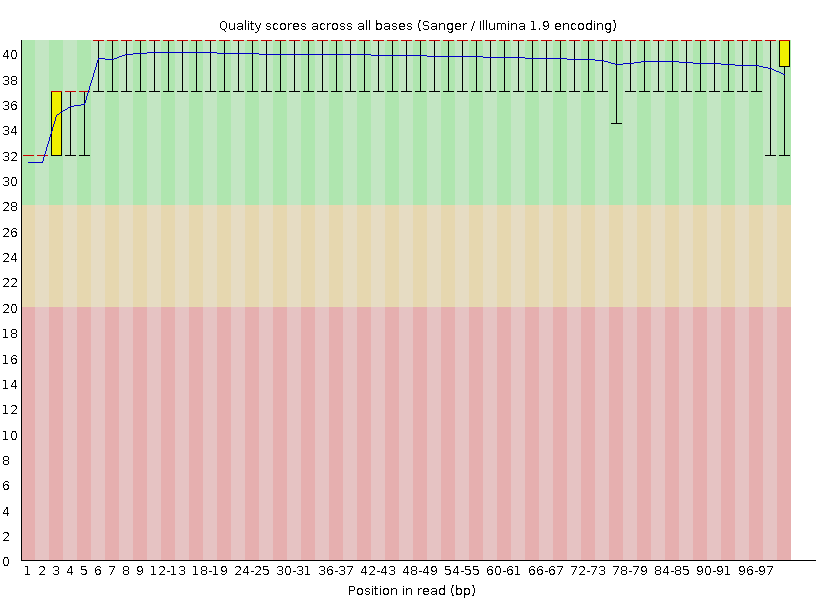

**Per Base Quality Score Distribution**

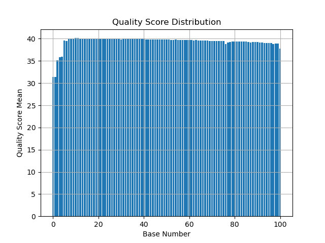

**Per Base Quality Score**

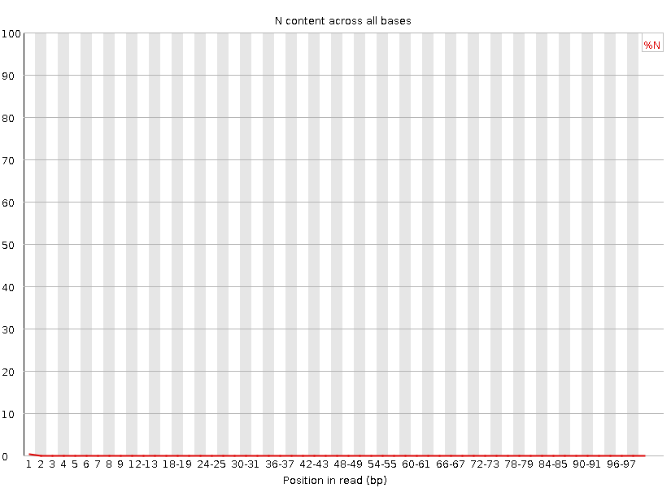

## 15_3C_mbnl_S11_L008 Read 2

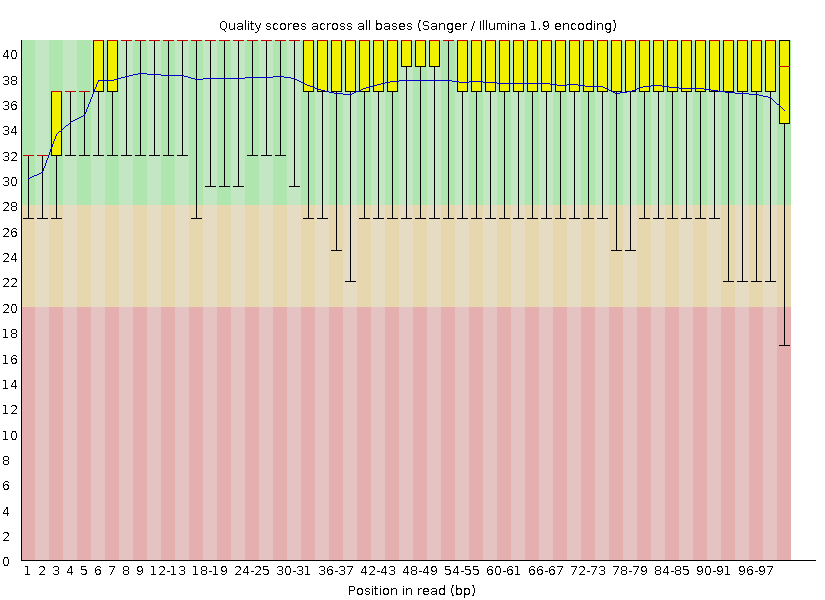

**Per Base Quality Score Distribution**

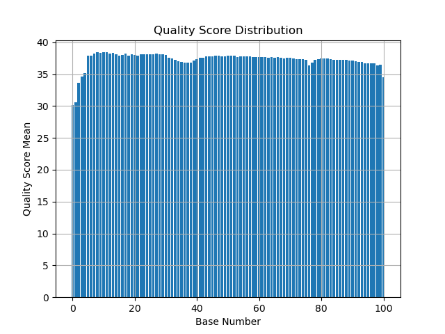

**Per Base Quality Score**

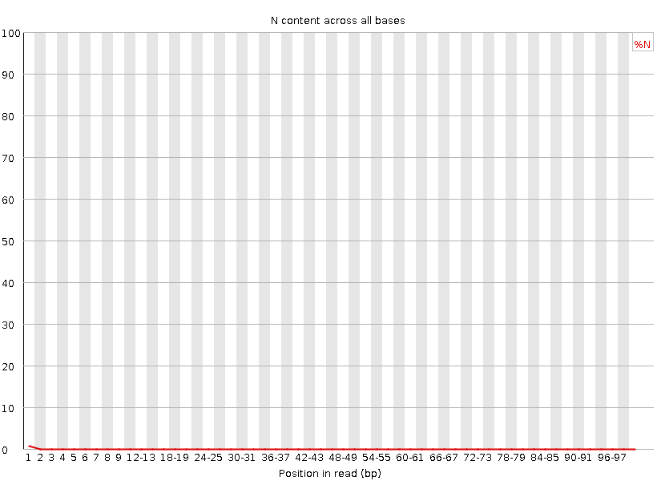

## 24_4A_control_S18_L008 Read 1

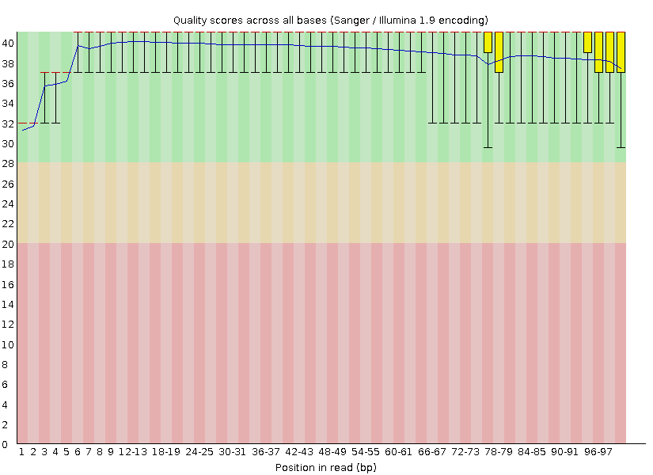

**Per Base Quality Score Distribution**

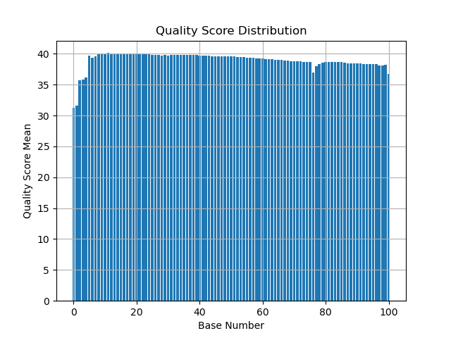

**Per Base Quality Score**

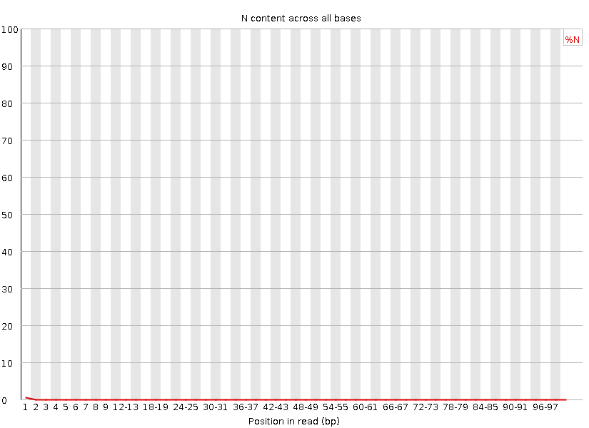

## 24_4A_control_S18_L008 Read 2

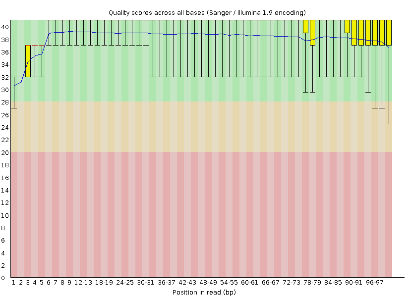

**Per Base Quality Score Distribution**

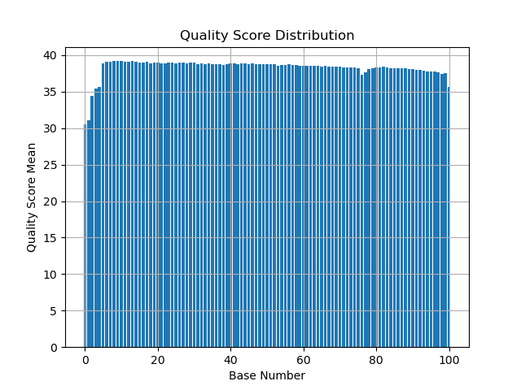

**Per Base Quality Score**

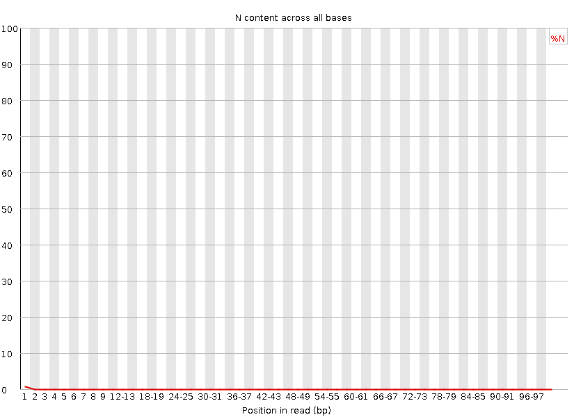

**Per Base N Content**

##### **Question 1**

> All paired graphs are consistent with each other. Increased N content is correlated with a decreased quality score. This is most visually distinct in base position 1.  
> Example code:  
> **fastqc /projects/bgmp/shared/2017_sequencing/demultiplexed/15_3C_mbnl_S11_L008_R1_001.fastq.gz -o .**

#argparse  
parser = argparse.ArgumentParser()  
parser.add_argument(“-R_file”, default=1)

args = parser.parse_args()  
file = args.R_file

#Reads with 101 characters  
phred_list =[]  
fred_list =Bioinfo.populate_list(file)  
phred_list = fred_list[0]  
#sums_list = phred_list[:]  
line_count = fred_list[1]

print(“phred_list output:”, phred_list)  
print(“line_count output:”, line_count)

count = 0  
for value in phred_list:  
phred_list[count] = value/(line_count/4)  
count += 1

plt.bar(range(101), phred_list)  
plt.title(‘Quality Score Distribution’)  
plt.xlabel(‘Base Number’)  
plt.ylabel(‘Quality Score Mean’)  
plt.grid(True)  
plt.savefig(“/home/jjacobso/bgmp/bioinformatics/Bi623/Assignments/QAA/24_R2.png”)  
plt.show()

##### **Question 2**

> The graphs generated using part of the demultiplexing script display nearly the same information as those produced through fastqc. The main difference is that fastqc provides a range of scores and a trendline. The python graphs allign almost perfectly to the trendline.  
> Runtime:  
> - Fastqc: 1minute 30seconds.  
> - Python: 2minutes 45seconds.  
> Fastqc is written in java which is a compiled language and generally faster than python. It was able to generate numerous figures in the time it took python to produce one.

##### **Question3**

> Both libraries follow the same pattern. The quality scores near the earliest base positions are the lowest, hovering at 32 for R1 and 30 for R2. The rest of the qscores are around 39/40 for R1 and 37/38 for R2. The last nucleotide of each library and read also has lower quality. R1 is higher quality than R2 for both libraries because it was subjected to less chemicals and had less time to degrade before sequencing.

## **Adapter Trimming Comparison**

#### Pt. 1: Cutadapt

> Example code:  
> **cutadapt -b AGATCGGAAGAGCACACGTCTGAACTCCAGTCA -o ./15_R1.fastq /projects/bgmp/shared/2017_sequencing/demultiplexed/15_3C_mbnl_S11_L008_R1_001.fastq**  
> Average Runtime: 1minute 30seconds Results:  
> 15_3C_mbnl_S11_L008_R1_001:  
> Adapter:AGATCGGAAGAGCACACGTCTGAACTCCAGTCA -Trimmed 554754x (7.1%)  
> 15_3C_mbnl_S11_L008_R2_001:  
> Adapter:AGATCGGAAGAGCGTCGTGTAGGGAAAGAGTGT -Trimmed 582968x (7.5%)  
> 24_4A_control_S18_L008_R1_001:  
> Adapter:AGATCGGAAGAGCACACGTCTGAACTCCAGTCA -Trimmed 489040x (4.7%) 24_4A_control_S18_L008_R2_001:  
> Adapter:AGATCGGAAGAGCGTCGTGTAGGGAAAGAGTGT -Trimmed 598531x (5.7%)

#### Pt. 2: Trimmomatic

> Example code:  
> **trimmomatic PE -threads 8 /home/jjacobso/bgmp/bioinformatics/Bi623/Assignments/QAA/15_R1.fastq /home/jjacobso/bgmp/bioinformatics/Bi623/Assignments/QAA/15_R2.fastq 15_R1_001_trimmo.fastq.gz 15_R1_001_untrimmo.fastq.gz 15_R2_001_trimmo.fastq.gz 15_R2_001_untrimmo.fastq.gz LEADING:3 TRAILING:3 SLIDINGWINDOW:5:15 MINLEN:35**  
> Average Runtime: 4minutes 37seconds

##### Trimmed Reads Results

**Library: 15_3C_mbnl_S11_L008_R1/R2_001_fastq**  
Input Read Pairs: 7806403 Both Surviving: 7418603 (95.03%) Forward Only Surviving: 377796 (4.84%) Reverse Only Surviving: 5705 (0.07%) Dropped: 4299 (0.06%)  
**Library: 24_4A_control_S18_L008_R1/R2_001_fastq**  
Input Read Pairs: 10515874 Both Surviving: 10245586 (97.43%) Forward Only Surviving: 255904 (2.43%) Reverse Only Surviving: 10860 (0.10%) Dropped: 3524 (0.03%)

#### Trimmed Read Distribution Plot

[figure not shown]

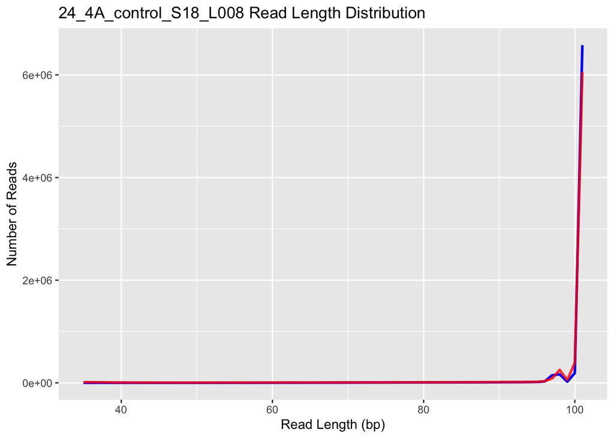

## Alignment and Strand-Specificity

#### STAR Assembly:

> Example Code:  
> **STAR –runThreadN 8 –runMode genomeGenerate –genomeDir /projects/bgmp/jjacobso/bioinformatics/Bi623/Assignments/QAA/Alignment_stuff/Mus_musculus.GRCm39.dna.ens104.star_2.7.9a –genomeFastaFiles /projects/bgmp/jjacobso/bioinformatics/Bi623/Assignments/QAA/Alignment_stuff/Mus_musculus.GRCm39.dna.primary_assembly.fa –sjdbGTFfile /projects/bgmp/jjacobso/bioinformatics/Bi623/Assignments/QAA/Alignment_stuff/Mus_musculus.GRCm39.104.gtf**  
> Runtime: 19minutes 17 seconds

#### STAR Alignment:

> Example code:  
> **STAR –runThreadN 8 –runMode alignReads –outFilterMultimapNmax 3 –outSAMunmapped Within KeepPairs –alignIntronMax 1000000 –alignMatesGapMax 1000000 –readFilesCommand zcat –readFilesIn /home/jjacobso/bgmp/bioinformatics/Bi623/Assignments/QAA/15_R1_001_trimmo.fastq.gz /home/jjacobso/bgmp/bioinformatics/Bi623/Assignments/QAA/15_R2_001_trimmo.fastq.gz –genomeDir /projects/bgmp/jjacobso/bioinformatics/Bi623/Assignments/QAA/Alignment_stuff/Mus_musculus.GRCm39.dna.ens104.star_2.7.9a –outFileNamePrefix Mus_musculus_15_R2_001**  
> Runtime: 1minute 16seconds

##### Mus_musculus_15_001_Aligned.out.sam

> Mapped Reads: 14432097 (97.3%)  
> Unmapped Reads: 405109 (2.7%)

*Mapped and Unmapped reads were found using Map_reader.py*

#! /usr/bin/python3.6

alignment_tracker = {}  
mapped = 0  
unmapped = 0  
with open (“/projects/bgmp/jjacobso/bioinformatics/Bi623/Assignments/QAA/Alignment_stuff/Mus_musculus_24_001Aligned.out.sam”, “r”) as fh:  
for line in fh:  
if not line.startswith(“@”):  
line = line.split(")  
flag = (int(line[1]))  
if((flag & 4) != 4) and ((flag & 256) != 256):  
mapped +=1  
else:  
if ((flag & 256) != 256):  
unmapped +=1

print (“Mapped read count:”, mapped)  
print(“Unmapped read count:”, unmapped)

### HTSeq Results

#### HTSeq:

> Example code:  
> **htseq-count stranded=yes Mus_musculus_24_001Aligned.out.sam Mus_musculus.GRCm39.104.gtf > Mus_musculus_24_001_stranded_Aligned.out.sam**

#### Proportion of mapped reads:

> Example code:  
> **grep -v “\t0$” Mus_musculus_15_001_stranded_Aligned.out.sam | awk ‘{if ($1 ~ “ENS.*”) sum+=$2; else sum_two+=$2} END {print (sum/(sum_two+sum))}’**

#### HtSeq Results

> **Mus_musculus_15_001_stranded_Aligned.out.sam**  
> __no_feature 6612743  
> __ambiguous 6184  
> __too_low_aQual 13778  
> __not_aligned 195207  
> __alignment_not_unique 325109  
> Proportion of mapped reads = **0.0357995**  
> **Mus_musculus_15_001_unstranded_Aligned.out.sam**  
> __no_feature 559675  
> __ambiguous 341555  
> __too_low_aQual 13778  
> __not_aligned 195207  
> __alignment_not_unique 325109  
> Proportion of mapped reads = **0.806524**  
> **Mus_musculus_24_001_stranded_Aligned.out.sam**  
> __no_feature 9052611  
> __ambiguous 7141  
> __too_low_aQual 11069  
> __not_aligned 350360  
> __alignment_not_unique 481260  
> Proportion of mapped reads = **0.033492**  
> **Mus_musculus_24_001_unstranded_Aligned.out.sam**  
> __no_feature 829369  
> __ambiguous 446219  
> __too_low_aQual 11069  
> __not_aligned 350360  
> __alignment_not_unique 481260  
> Proportion of mapped reads = **0.79325**